# Simulation design and workflow

This file shows two things:

1. The simulation design: all conditions of each grid.
2. The workflow: the Snakemake rules and the order in which they run.

All values come from the files in `config/`. The data generating processes are in `dgp_models.Rmd`.

# Simulation design

## Configurations

Each config file selects one cell table and sets the global values. Run a config with `snakemake --configfile config/<name>.yaml`. The default in `workflow/Snakefile` is `config/small.yaml`.

| Config | Purpose |
| --- | --- |
| `paper` | Reproduction of Fig. 5 and 6 in Sivula et al. (2025). Gaussian family and `elpd` only. |
| `full` | Extension: the full grid of `simulated/setup_all.py`, for all families and measures. |
| `small` | Extension on a small grid: a quick test on a laptop. |

```r
config_files <- c(small = "config/small.yaml", paper = "config/paper.yaml",
                  full = "config/full.yaml")
configs <- lapply(config_files, yaml::read_yaml)
# A config has no n_sets_test_<family> for a family without cells.
or_na <- function(x) if (is.null(x)) NA else x

knitr::kable(t(sapply(configs, function(cfg) c(
  cells = cfg$cells,
  results = cfg$results,
  n_sets_train = cfg$n_sets_train,
  n_sets_test_gaussian = cfg$n_sets_test_gaussian,
  n_sets_test_binomial = or_na(cfg$n_sets_test_binomial),
  n_sets_test_poisson = or_na(cfg$n_sets_test_poisson),
  seed = cfg$seed
)))
)
```

|  | cells | results | n_sets_train | n_sets_test_gaussian | n_sets_test_binomial | n_sets_test_poisson | seed |
| --- | --- | --- | --- | --- | --- | --- | --- |
| small | config/cells_small.tsv | results/small | 100 | 200 | 50 | 20 | 2958319 |
| paper | config/cells_paper.tsv | results/paper | 2000 | 4000 | NA | NA | 2958319 |
| full | config/cells_full.tsv | results/full | 2000 | 4000 | 250 | 50 | 2958319 |

- `n_sets_train`: the number of training sets (trials) in each cell.
- `n_sets_test_gaussian`, `n_sets_test_binomial`, `n_sets_test_poisson`: the number of test sets in each cell. The test sets are pooled into one test sample.

The measures of each config, for each family. A dash marks a family without cells in the config. Rule `score` computes the pointwise scores that the measures need.

```r
source("workflow/scripts/lib/measures.R")
families <- c("gaussian", "binomial", "poisson")

knitr::kable(t(sapply(configs, function(cfg) {
  in_cells <- unique(read.delim(cfg$cells)$family)
  sapply(families, function(f) {
    if (!f %in% in_cells) return("-")
    paste(measures_for_family(cfg$measures, f), collapse = ", ")
  })
})))
```

|  | gaussian | binomial | poisson |
| --- | --- | --- | --- |
| small | elpd, mlpd, ic, mse, mae, rmse, r2, rps, srps | elpd, mlpd, ic, mse, mae, rmse, r2, rps, srps, brier, acc, bacc | elpd, mlpd, ic, mse, mae, rmse, r2, rps, srps |
| paper | elpd | - | - |
| full | elpd, mlpd, ic, mse, mae, rmse, r2, rps, srps | elpd, mlpd, ic, mse, mae, rmse, r2, rps, srps, brier, acc, bacc | elpd, mlpd, ic, mse, mae, rmse, r2, rps, srps |

The measures `brier`, `acc` and `bacc` apply to the binomial family only.

## Fixed settings

These settings are the same in all cells:

| Setting | Value | Source |
| --- | --- | --- |
| Columns of $X$, $D$ | 3 (intercept, $x_1$, $x_2$) | `make_beta_coeff()` |
| Coefficients $\beta$ | $(0, 1, \beta_t)$ | `make_beta_coeff()` |
| Number of outliers | 1 (the first observation) | `n_obs_out` |
| Gaussian noise variance $\sigma^2$ | 1 | `sigma2_d` |
| Model A | columns 1 and 2 of $X$ | `model_columns()` |
| Model B | columns 1 to 3 of $X$ | `model_columns()` |

So model A omits the covariate with the coefficient $\beta_t$.

## Factors

A cell is one combination of the factors below. The factors are crossed within each family.

| Factor | Column | Meaning |
| --- | --- | --- |
| Family | `family` | Gaussian, binomial or Poisson DGP and model |
| $n$ | `n_obs` | observations in one training set |
| $\beta_t$ | `beta_t` | coefficient that only model B has |
| $\Delta$ | `out_dev` | outlier deviation (scale differs by family) |

```r
cells <- lapply(configs, function(cfg) {
  read.delim(cfg$cells, stringsAsFactors = FALSE)
})

levels_of <- function(x) paste(sort(unique(x)), collapse = ", ")

factor_table <- do.call(rbind, lapply(names(cells), function(grid) {
  d <- cells[[grid]]
  do.call(rbind, lapply(split(d, d$family), function(f) data.frame(
    grid = grid,
    family = f$family[1],
    n_obs = levels_of(f$n_obs),
    beta_t = levels_of(f$beta_t),
    out_dev = levels_of(f$out_dev),
    cells = nrow(f),
    chunks = sum(f$n_chunks)
  )))
}))
rownames(factor_table) <- NULL
knitr::kable(factor_table)
```

| grid | family | n_obs | beta_t | out_dev | cells | chunks |
| --- | --- | --- | --- | --- | --- | --- |
| small | binomial | 16, 64 | 0, 1 | 0, 5 | 8 | 8 |
| small | gaussian | 16, 64 | 0, 1 | 0, 20 | 8 | 12 |
| small | poisson | 16, 64 | 0, 1 | 0, 2 | 8 | 12 |
| paper | gaussian | 32, 128, 512 | 0, 0.2, 1 | 0, 20 | 18 | 66 |
| full | binomial | 16, 32, 64, 128, 256, 512, 1024 | 0, 0.05, 0.1, 0.2, 0.5, 1 | 0, 2, 5 | 126 | 126 |
| full | gaussian | 16, 32, 64, 128, 256, 512, 1024 | 0, 0.05, 0.1, 0.2, 0.5, 1 | 0, 20, 200 | 126 | 198 |
| full | poisson | 16, 32, 64, 128, 256, 512, 1024 | 0, 0.05, 0.1, 0.2, 0.5, 1 | 0, 1, 2 | 126 | 198 |

`chunks` is the total number of chunks. A chunk is a part of the trials of one cell. Rule `fit`, rule `score` and rule `compare` run once for each chunk.

## Size of each grid

```r
knitr::kable(do.call(rbind, lapply(names(cells), function(grid) {
  d <- cells[[grid]]
  n_sets_train <- configs[[grid]]$n_sets_train
  data.frame(
    grid = grid,
    cells = nrow(d),
    trials = nrow(d) * n_sets_train,
    model_fits = 2 * nrow(d) * n_sets_train,
    training_observations = n_sets_train * sum(d$n_obs)
  )
})))
```

| grid | cells | trials | model_fits | training_observations |
| --- | --- | --- | --- | --- |
| small | 24 | 2400 | 4800 | 96000 |
| paper | 18 | 36000 | 72000 | 8064000 |
| full | 378 | 756000 | 1512000 | 219456000 |

`model_fits` counts one fit of model A and one fit of model B in each trial. Each fit also computes the LOO predictive of all $n$ observations.

## All cells

The cell name encodes the factors. For example, `bin_n64_b1_o5` is the binomial cell with $n = 64$, $\beta_t = 1$ and $\Delta = 5$.

**Cells of the full grid (click to open)**

| cell | family | n_obs | beta_t | out_dev | n_chunks |
| --- | --- | --- | --- | --- | --- |
| n16_b0_o0 | gaussian | 16 | 0.00 | 0 | 1 |
| n16_b0_o20 | gaussian | 16 | 0.00 | 20 | 1 |
| n16_b0_o200 | gaussian | 16 | 0.00 | 200 | 1 |
| n16_b0.05_o0 | gaussian | 16 | 0.05 | 0 | 1 |
| n16_b0.05_o20 | gaussian | 16 | 0.05 | 20 | 1 |
| n16_b0.05_o200 | gaussian | 16 | 0.05 | 200 | 1 |
| n16_b0.1_o0 | gaussian | 16 | 0.10 | 0 | 1 |
| n16_b0.1_o20 | gaussian | 16 | 0.10 | 20 | 1 |
| n16_b0.1_o200 | gaussian | 16 | 0.10 | 200 | 1 |
| n16_b0.2_o0 | gaussian | 16 | 0.20 | 0 | 1 |
| n16_b0.2_o20 | gaussian | 16 | 0.20 | 20 | 1 |
| n16_b0.2_o200 | gaussian | 16 | 0.20 | 200 | 1 |
| n16_b0.5_o0 | gaussian | 16 | 0.50 | 0 | 1 |
| n16_b0.5_o20 | gaussian | 16 | 0.50 | 20 | 1 |
| n16_b0.5_o200 | gaussian | 16 | 0.50 | 200 | 1 |
| n16_b1_o0 | gaussian | 16 | 1.00 | 0 | 1 |
| n16_b1_o20 | gaussian | 16 | 1.00 | 20 | 1 |
| n16_b1_o200 | gaussian | 16 | 1.00 | 200 | 1 |
| n32_b0_o0 | gaussian | 32 | 0.00 | 0 | 1 |
| n32_b0_o20 | gaussian | 32 | 0.00 | 20 | 1 |
| n32_b0_o200 | gaussian | 32 | 0.00 | 200 | 1 |
| n32_b0.05_o0 | gaussian | 32 | 0.05 | 0 | 1 |
| n32_b0.05_o20 | gaussian | 32 | 0.05 | 20 | 1 |
| n32_b0.05_o200 | gaussian | 32 | 0.05 | 200 | 1 |
| n32_b0.1_o0 | gaussian | 32 | 0.10 | 0 | 1 |
| n32_b0.1_o20 | gaussian | 32 | 0.10 | 20 | 1 |
| n32_b0.1_o200 | gaussian | 32 | 0.10 | 200 | 1 |
| n32_b0.2_o0 | gaussian | 32 | 0.20 | 0 | 1 |
| n32_b0.2_o20 | gaussian | 32 | 0.20 | 20 | 1 |
| n32_b0.2_o200 | gaussian | 32 | 0.20 | 200 | 1 |

[output cut: 348 more lines]

# Workflow

## Rule graph

The graph shows the rules and the files that connect them. The rules in the grey box run once for each cell, or for each chunk of a cell. The other rules run once for the whole grid, or once for each figure. A dashed arrow carries only the Gaussian `elpd` figure.

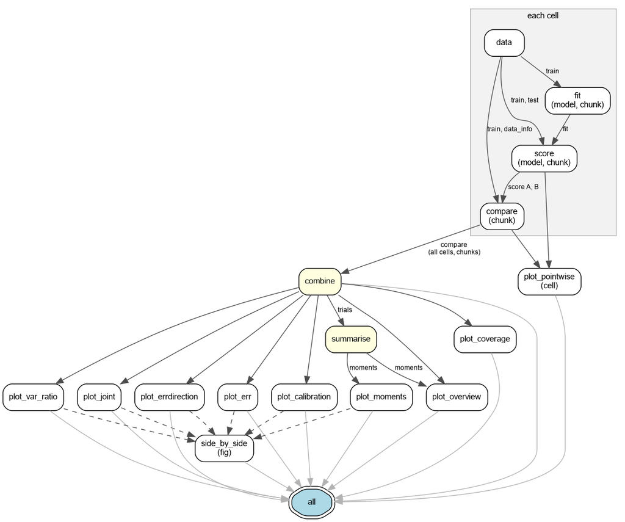

Rules of the workflow. An arrow goes from the rule that writes a file to the rule that reads it.

## Rules

The rules are in `workflow/rules/`. All results go into the `results` folder of the config, here written as `RES`.

| Order | Rule | Runs once for each | Input | Output | Script |
| --- | --- | --- | --- | --- | --- |
| 1 | `data` | cell | cell parameters | `{cell}/train.rds`, `{cell}/test.rds` (temp), `{cell}/data_info.rds` | `generate_data.R` |
| 2 | `fit` | cell, model, chunk | `train.rds` | `{cell}/fit/{model}_{chunk}.rds` | `fit.R` |
| 3 | `score` | cell, model, chunk | `fit`, `train.rds`, `test.rds` | `{cell}/score/{model}_{chunk}.rds` | `score.R` |
| 4 | `compare` | cell, chunk | `score` A and B, `train.rds`, `data_info.rds` | `{cell}/compare/{chunk}.rds` | `compare.R` |
| 5 | `combine` | grid | all `compare` files | `trials.rds` | `combine.R` |
| 6 | `summarise` | grid | `trials.rds` | `moments.rds` | `summarise.R` |
| 7 | `plot_calibration` | family, measure | `trials.rds` | `figs/calibration_{family}_{measure}.pdf` | `plot_calibration.R` |
| 7 | `plot_joint` | family, measure | `trials.rds` | `figs/joint_{family}_{measure}.pdf` | `plot_joint.R` |
| 7 | `plot_var_ratio` | family, measure | `trials.rds` | `figs/var_ratio_{family}_{measure}.pdf` | `plot_var_ratio.R` |
| 7 | `plot_err` | family, measure | `trials.rds` | `figs/err_{family}_{measure}.pdf` | `plot_err.R` |
| 7 | `plot_errdirection` | family, measure | `trials.rds` | `figs/errdirection_{family}_{measure}.pdf` | `plot_err.R` |
| 7 | `plot_coverage` | grid | `trials.rds` | `figs/coverage_*.pdf`, `coverage_cutoffs.csv` | `plot_coverage.R` |
| 7 | `plot_moments` | family, measure | `moments.rds` | `figs/moments_{family}_{measure}.pdf` | `plot_moments.R` |
| 7 | `plot_overview` | family, measure | `trials.rds`, `moments.rds` | `figs/overview_{family}_{measure}.pdf` | `plot_overview.R` |
| 7 | `plot_pointwise` | plotted cell | `score` and `compare` of the cell | `figs/pointwise_{cell}.pdf` | `plot_pointwise.R` |
| 8 | `side_by_side` | paper figure | paper PDF, `figs/{fig}_gaussian_elpd.pdf` | `figs/side_by_side_{fig}.pdf` | `side_by_side.R` |
| 9 | `all` | grid | `trials.rds`, all figures |  |  |

- Rules with the same order number do not depend on each other. Snakemake can run them in parallel.
- `fit`, `score` and `compare` are in the group `chunk`. On Slurm, one job runs the three rules of one chunk.
- `train.rds` and `test.rds` are temporary. Snakemake deletes them after the last `score` and `compare` job of the cell.
- `side_by_side` runs only if the config has `paper_figs`.

## Number of jobs

The table counts the jobs of each rule, as `workflow/rules/common.smk` defines them.

```r
MEASURES_BINARY <- c("brier", "acc", "bacc")
FIGS_PER_MEASURE <- c("calibration", "joint", "moments", "var_ratio",
                      "err", "errdirection", "overview")

# Mirrors plot_cells() in workflow/rules/common.smk.
plot_cells <- function(cfg, d) {
  keep <- vapply(seq_len(nrow(d)), function(i) {
    sel <- cfg$plot
    sel[names(cfg[[paste0("plot_", d$family[i])]])] <-
      cfg[[paste0("plot_", d$family[i])]]
    d$n_obs[i] %in% sel$n_obs &&
      d$beta_t[i] %in% as.numeric(sel$beta_t) &&
      d$out_dev[i] %in% as.numeric(sel$out_dev)
  }, logical(1))
  d$cell[keep]
}

jobs <- do.call(cbind, lapply(names(cells), function(grid) {
  cfg <- configs[[grid]]
  d <- cells[[grid]]
  families <- unique(d$family)
  # Measures of each family, as family_measures() in common.smk.
  n_measures <- sum(vapply(families, function(f) {
    if (f == "binomial") length(cfg$measures)
    else length(setdiff(cfg$measures, MEASURES_BINARY))
  }, numeric(1)))
  chunks <- sum(d$n_chunks)
  per_fig <- n_measures
  setNames(data.frame(c(
    data = nrow(d),
    fit = 2 * chunks,
    score = 2 * chunks,
    compare = chunks,
    combine = 1,
    summarise = 1,
    plot_calibration = per_fig,
    plot_joint = per_fig,
    plot_var_ratio = per_fig,
    plot_err = per_fig,
    plot_errdirection = per_fig,
    plot_moments = per_fig,
    plot_overview = per_fig,
    plot_coverage = 1,
    plot_pointwise = length(plot_cells(cfg, d)),
    side_by_side = length(cfg$paper_figs),
    all = 1
  )), grid)
}))
jobs <- rbind(jobs, total = colSums(jobs))
knitr::kable(jobs)
```

|  | small | paper | full |
| --- | --- | --- | --- |
| data | 24 | 18 | 378 |
| fit | 64 | 132 | 1044 |
| score | 64 | 132 | 1044 |
| compare | 32 | 66 | 522 |
| combine | 1 | 1 | 1 |
| summarise | 1 | 1 | 1 |
| plot_calibration | 30 | 1 | 30 |
| plot_joint | 30 | 1 | 30 |
| plot_var_ratio | 30 | 1 | 30 |
| plot_err | 30 | 1 | 30 |
| plot_errdirection | 30 | 1 | 30 |
| plot_moments | 30 | 1 | 30 |
| plot_overview | 30 | 1 | 30 |
| plot_coverage | 1 | 1 | 1 |
| plot_pointwise | 24 | 18 | 147 |
| side_by_side | 0 | 6 | 6 |
| all | 1 | 1 | 1 |
| total | 422 | 383 | 3355 |

Each `plot_*` rule with the wildcards family and measure runs once for each measure of each family. The Gaussian and the Poisson families have 9 measures. The binomial family has 12.